# Spatial Analysis with R: Exercise 2: Basic R Operations

### ### IMPORTING DATA

**# Bundled datasets**  
# Many R packages come with bundled data sets. The `data()` function will list  
# available datasets from the *datasets* package. You generally don’t have to ‘load’  
# a bundled dataset into memory, R will automatically bring them in when needed.  
# Most datasets also have a help page that explain their contents, that you can view  
# in the same way you view help page for a function.

# 11. Explore the *iris* dataset: What type of object (class) is it? What columns does it  
# contain? What do the numbers represent?

```r
class(iris)
```

```
## [1] "data.frame"
```

```r
head(iris)
```

```
##   Sepal.Length Sepal.Width Petal.Length Petal.Width Species
## 1          5.1         3.5          1.4         0.2  setosa
## 2          4.9         3.0          1.4         0.2  setosa
## 3          4.7         3.2          1.3         0.2  setosa
## 4          4.6         3.1          1.5         0.2  setosa
## 5          5.0         3.6          1.4         0.2  setosa
## 6          5.4         3.9          1.7         0.4  setosa
```

To open the help page:

```r
?iris
# or:
help("iris")
```

**# csv files**  
# The raster package comes with a csv file called countries.csv. To find out where  
# it is located on your hard drive, run  
# `system.file("external/countries.csv", package="raster")`.

# 12. Import *countries.csv* as a dataframe and save it as *countriesDF*. Use the *summary()* function to see what each column contains.

```r
fn <- system.file("external/countries.csv", package="raster")
fn
```

```
## [1] "C:/Users/Andy/Documents/R/win-library/3.4/raster/external/countries.csv"
```

```r
countriesDF <- read.csv(fn)
summary(countriesDF)
```

```
##                     NAME          ISO3          ISO2
##  Ãland               :  1   ABW    :  1   10     :  1
##  Afghanistan          :  1   AFG    :  1   11     :  1
##  Akrotiri and Dhekelia:  1   AGO    :  1   12     :  1
##  Albania              :  1   AIA    :  1   13     :  1
##  Algeria              :  1   ALA    :  1   16     :  1
##  American Samoa       :  1   ALB    :  1   (Other):250
##  (Other)              :250   (Other):250   NA's   :  1
##                   NAME_ISO             NAME_FAO
##                       :  4                 : 39
##  <Null>               :  1   Afghanistan   :  1
##  ÃLAND ISLANDS       :  1   Albania       :  1
##  AFGHANISTAN          :  1   Algeria       :  1
##  AKROTIRI AND DHEKELIA:  1   American Samoa:  1
##  ALBANIA              :  1   Andorra       :  1
##  (Other)              :247   (Other)       :212
##                  NAME_LOCAL           SOVEREIGN                UNREGION1
##                       :  5   United Kingdom: 16   Caribbean         : 28
##  Ãsterreich          :  1                 : 12   Western Asia      : 20
##  Ãland               :  1   France        : 11   Eastern Africa    : 19
##  Ãire                :  1   United States :  8   Southern Europe   : 17
##  Afghanestan          :  1   Australia     :  5   Western Africa    : 17
##  Akrotiri and Dhekelia:  1   New Zealand   :  4   South-Eastern Asia: 15
##  (Other)              :246   (Other)       :200   (Other)           :140
##      UNREGION2          CONTINENT
##           : 3   Africa       :59
##  Africa   :58   Antarctica   : 4
##  Americas :56   Asia         :62
##  Antartica: 4   Europe       :52
##  Asia     :58   North America:38
##  Europe   :52   Oceania      :23
##  Oceania  :25   South America:18
```

### ### TWO-DIMENSIONAL DATA STRUCTURES

# The main two-dimensional data structures in R are *matrices* and *data frames*.  
# The big differences between the two are that:  
# i) all the elements of matrices have to be the same data type (usually numeric)  
# whereas each column of a dataframe can be a different data type  
# ii) the columns of a data frame are usually named, and you can reference them by name

# 13. Display the column names of the *countriesDF* you just imported. Then make them all lowercase  
# (hint: *tolower()* returns a lowercase version of its argument).

```r
names(countriesDF)
```

```
##  [1] "NAME"       "ISO3"       "ISO2"       "NAME_ISO"   "NAME_FAO"
##  [6] "NAME_LOCAL" "SOVEREIGN"  "UNREGION1"  "UNREGION2"  "CONTINENT"
```

```r
names(countriesDF) <- tolower(names(countriesDF))
names(countriesDF)
```

```
##  [1] "name"       "iso3"       "iso2"       "name_iso"   "name_fao"
##  [6] "name_local" "sovereign"  "unregion1"  "unregion2"  "continent"
```

# 14. How many rows are there in the *iris* data frame?

```r
nrow(iris)
```

```
## [1] 150
```

# 15. Write an expression that returns the names of the species in *iris*.

```r
unique(iris$Species)
```

```
## [1] setosa     versicolor virginica
## Levels: setosa versicolor virginica
```

# 16. Write an expression that returns all columns from *iris* but only the rows for the species *virginica*.

```r
iris[iris$Species=="virginica", ]
```

```
##     Sepal.Length Sepal.Width Petal.Length Petal.Width   Species
## 101          6.3         3.3          6.0         2.5 virginica
## 102          5.8         2.7          5.1         1.9 virginica
## 103          7.1         3.0          5.9         2.1 virginica
## 104          6.3         2.9          5.6         1.8 virginica
## 105          6.5         3.0          5.8         2.2 virginica
## 106          7.6         3.0          6.6         2.1 virginica
## 107          4.9         2.5          4.5         1.7 virginica
## 108          7.3         2.9          6.3         1.8 virginica
## 109          6.7         2.5          5.8         1.8 virginica
## 110          7.2         3.6          6.1         2.5 virginica
## 111          6.5         3.2          5.1         2.0 virginica
## 112          6.4         2.7          5.3         1.9 virginica
## 113          6.8         3.0          5.5         2.1 virginica
## 114          5.7         2.5          5.0         2.0 virginica
```

[output cut: 36 more lines]

# 17. What is the mean, standard deviation, and quartiles of the petal length for the species *setosa*?

```r
setosa_petal <- iris[iris$Species=="setosa", "Petal.Length"]
mean(setosa_petal)
```

```
## [1] 1.462
```

```r
sd(setosa_petal)
```

```
## [1] 0.173664
```

```r
summary(setosa_petal)
```

```
##    Min. 1st Qu.  Median    Mean 3rd Qu.    Max.
##   1.000   1.400   1.500   1.462   1.575   1.900
```

# 18. Using the countries data frame you imported earlier, how many countries are there on the continent  
# of Africa?

```r
nrow(countriesDF[countriesDF$continent=="Africa",])
```

```
## [1] 59
```

```r
# or:
table(countriesDF$continent)
```

```
##
##        Africa    Antarctica          Asia        Europe North America
##            59             4            62            52            38
##       Oceania South America
##            23            18
```

### ### BASIC PLOTTING

# 19. Create a histogram of *state.area* (area of the 50 US states in square miles). Investigate what the  
# *breaks* argument does.

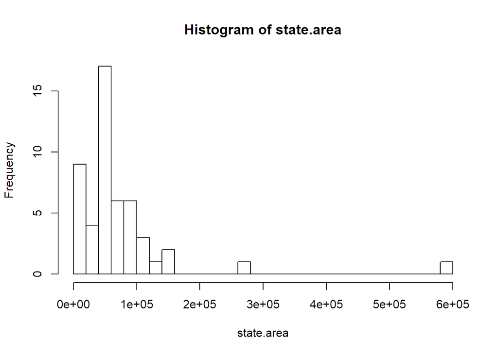

```r
hist(state.area, breaks=25)
```

The *breaks* argument specifies the number of bins, or the method used to determine the breakpoints.

# 20. Create a scatterplot of the sepal length vs petal length from *iris*. Does it look like they’re  
# correlated?

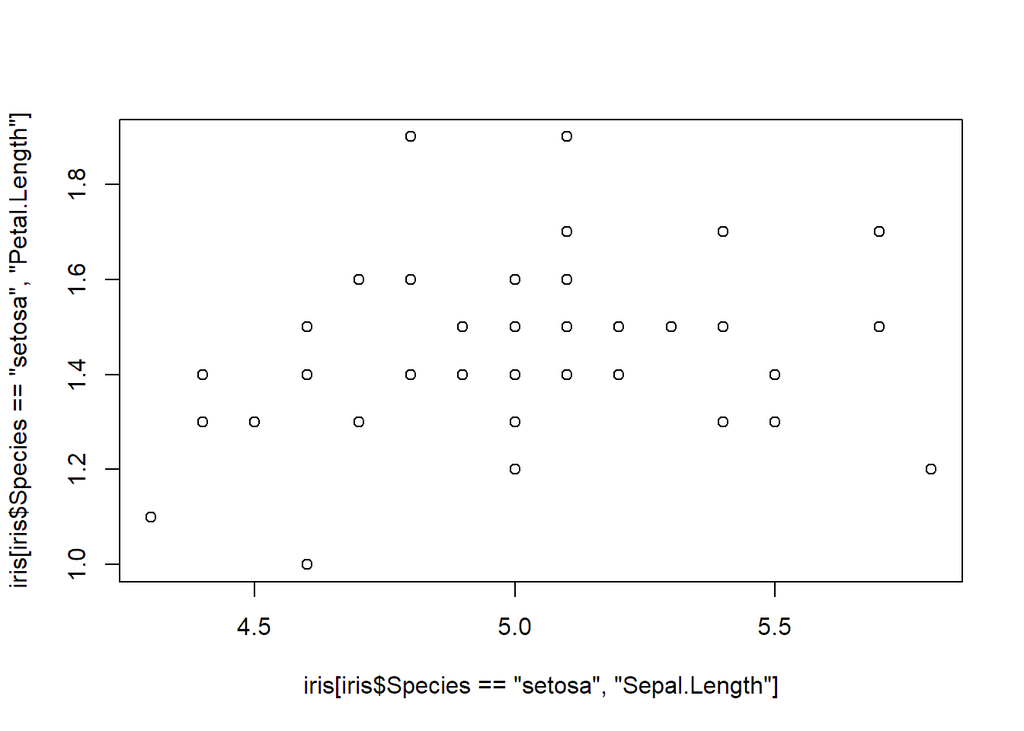

```r
plot(x=iris[iris$Species=="setosa", "Sepal.Length"], y=iris[iris$Species=="setosa", "Petal.Length"])
```

A nicer looking example with ggplot:

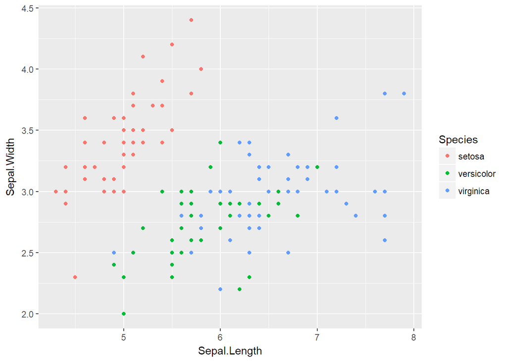

```r
library(ggplot2)
ggplot(data=iris, aes(x=Sepal.Length, y=Sepal.Width, color=Species)) + geom_point()
```

Course outline